# Strength Analysis of Bad Passwords

**Time**

- Teaching, 30 minutes.

**Questions:**

- Among bad passwords, what are the features of the strongest?
- How might we employ quantitative methods to explore password strength?

**Learning Objectives**

- “Analyze variables based on features identified in common passwords.”
- “Visualise the relationship between password strength variables to generate hypotheses.”
- “Test hypotheses using a multiple regression model.”

```r
# installing and loading packages
if (!require("pacman")) install.packages("pacman")
pacman::p_load(
  tidyverse, # wrangling and visualization.
  corrr      # tidy correlations.
)
```

#### What makes a good password?

To answer that question, we examine a dataset of *bad* passwords sourced from data breaches by the people at [Information is Beautiful](https://informationisbeautiful.net/visualizations/top-500-passwords-visualized/?utm_content=buffer994fa&utm_medium=social&utm_source=twitter.com&utm_campaign=buffer). We explore the features of these passwords, create and visualize a multivariate regression model to determine which of these password features are most protective from being cracked by malicious alorithms.

```r
# import dataset from URL link
passwords <- read_csv('https://raw.githubusercontent.com/rfordatascience/tidytuesday/master/data/2020/2020-01-14/passwords.csv',
            # restructure variables as factors
              col_types = cols(category = col_factor(),
                               time_unit = col_factor())) %>%
             # purge NA values.
              na.omit()

# evaluate structure of dataset.
glimpse(passwords)
```

```
## Rows: 500
## Columns: 9
## $ rank              <dbl> 1, 2, 3, 4, 5, 6, 7, 8, 9, 10, 11, 12, 13, 14, 15, 1…
## $ password          <chr> "password", "123456", "12345678", "1234", "qwerty", …
## $ category          <fct> password-related, simple-alphanumeric, simple-alphan…
## $ value             <dbl> 6.91, 18.52, 1.29, 11.11, 3.72, 1.85, 3.72, 6.91, 6.…
## $ time_unit         <fct> years, minutes, days, seconds, days, minutes, days, …
## $ offline_crack_sec <dbl> 2.170e+00, 1.110e-05, 1.110e-03, 1.110e-07, 3.210e-0…
## $ rank_alt          <dbl> 1, 2, 3, 4, 5, 6, 7, 8, 9, 10, 11, 12, 13, 14, 15, 1…
## $ strength          <dbl> 8, 4, 4, 4, 8, 4, 8, 4, 7, 8, 8, 1, 32, 9, 9, 8, 8, …
## $ font_size         <dbl> 11, 8, 8, 8, 11, 8, 11, 8, 11, 11, 11, 4, 23, 12, 12…
```

There are a few variables of interest in this dataset we use in this workflow:

- `category` describes the “genre” a password draws from.
- `strength` is a numerical measurement of password’s resiliency to being hacked.
- `password` is the password itself, which we will extract categorical features from to inform our regression model.

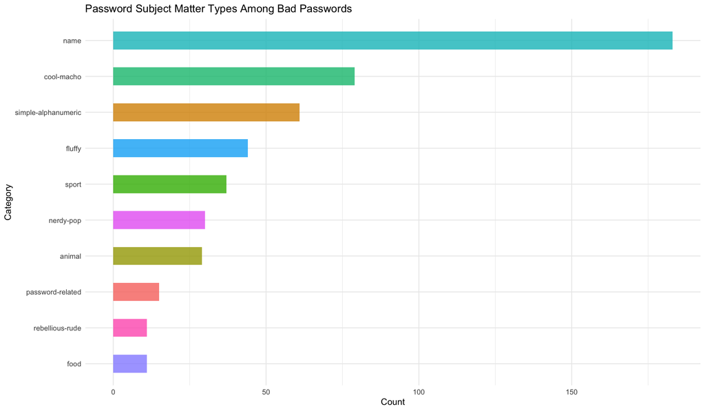

```r
# group and count by password category
 passwords %>%
  group_by(category) %>%
  count() %>%
# plot.
  ggplot(aes(x = reorder(category, n), y = n, fill = category)) +
  geom_col(alpha = .8, width = .5) +
  coord_flip() +
  ggtitle("Password Subject Matter Types Among Bad Passwords") +
  xlab("Category") +
  ylab("Count") +
  theme_minimal() +
  theme(legend.position = "NULL")
```

> We see that many bad passwords include some aspect of the user’s name, followed by `cool-macho` and `simple-alphanumeric` entries.

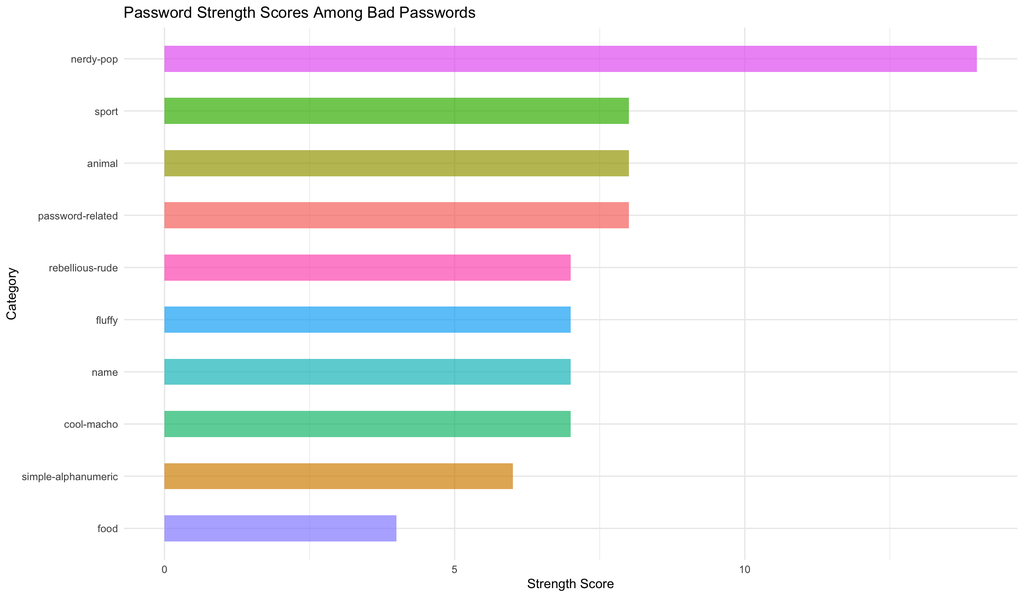

```r
passwords %>%
  group_by(category) %>%
  summarise(avg_strength = round(mean(strength))) %>%
  ggplot(aes(x = reorder(category, avg_strength), y = avg_strength,
             fill = category)) +
    geom_col(alpha = .7, width = .5) +
  coord_flip() +
   ggtitle("Password Strength Scores Among Bad Passwords") +
  xlab("Category") +
  ylab("Strength Score") +
  theme_minimal() +
  theme(legend.position = "NULL")
```

> Looking at an averaged Strength Score of these bad passwords, `nerdy-pop` genres appear strongest and passwords referencing `food` lack the most strength overall.

In the next chunk we create categorical features based upon the content of the `password` values. Which passwords contain only numbers? Only letters? Does a password repeat stuff? What are the differences in length of password, how many characters the password is composed of? These are the questions our newly transformed features variables can answer.

```r
## create features from the passwords variable
passwords_with_features <- passwords %>% mutate(
  # does password contain only numbers?
  all_num = ifelse(str_detect(password, "^[0-9]*$"), 1, 0),
  # does password contain only letters?
  all_let = ifelse(str_detect(password, "^[a-zA-Z]*$"), 1, 0),
  # does password contain repeated strings?
  rep_str = ifelse(str_detect(password, "\\b(\\S+?)\\1\\S*\\b"), 1, 0),
  # length of password
  pw_len = str_length(password),
  # combined flags in categorical variable
  pw_feat = paste0(
    ifelse(all_num == 1, "All numbers, ", ""),
    ifelse(all_let == 1, "All letters, ", ""),
    ifelse(all_num == 0 & all_let == 0, "Mixed numbers and letters, ", ""),
    ifelse(rep_str == 1, "repeated strings.", "no repeated strings."))) %>%
  filter(!is.na(password))


# summary of password features.
passwords_with_features %>%
  group_by(pw_feat) %>%
  summarize(pw_feature_count = n()) %>%
  arrange(pw_feature_count)
```

```
## # A tibble: 5 x 2
##   pw_feat                                         pw_feature_count
##   <chr>                                                      <int>
## 1 All letters, repeated strings.                                 8
## 2 All numbers, no repeated strings.                             14
## 3 Mixed numbers and letters, no repeated strings.               14
## 4 All numbers, repeated strings.                                26
## 5 All letters, no repeated strings.                            438
```

Everyday experience would suggest that password length: how many characters a password is composed of would be a protective element. Is that true? Let’s start looking at the relationship between our continous `pw_length` variable and the logged `strength` score.

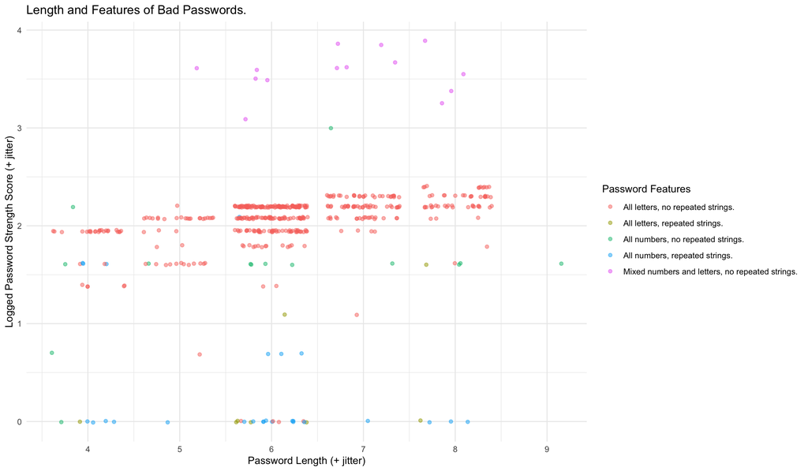

```r
## vizualize relationship between pw_length and strength.
passwords_with_features %>%
  ggplot() +
  geom_point(alpha = .5,
    aes(x = jitter(pw_len, 2),
        y = jitter(log(strength + 1), 2),
        col = pw_feat)) +
  xlab("Password Length (+ jitter)") +
  ylab("Logged Password Strength Score (+ jitter)") +
  labs(col = "Password Features") +
  ggtitle("Length and Features of Bad Passwords.") +
  theme_minimal()
```

Up at the top of this graph we see how stronger passwords have a mixture of letters and numbers. It also looks like letter-only passwords become stronger as more characters are used to create them.

#### Correlations between `pw_length` and `strength` variables:

```r
# Positive correlation between length and strength with all letter passwords
passwords_with_features %>%
  filter(str_detect(pw_feat, "All letters,")) %>%
  select(pw_len, strength) %>%
  correlate() %>% fashion()
```

```
##       term pw_len strength
## 1   pw_len             .48
## 2 strength    .48
```

```r
# Positive correlation between strength and no repeated strings
passwords_with_features %>%
  filter(pw_feat == "All letters, no repeated strings."|
         pw_feat == "All numbers, no repeated strings.") %>%
  select(pw_len, strength) %>%
  correlate() %>% fashion()
```

```
##       term pw_len strength
## 1   pw_len             .49
## 2 strength    .49
```

```r
# Negative correlation between strength and length with repeated strings
passwords_with_features %>%
  filter(pw_feat == "All numbers, repeated strings." |
         pw_feat == "All letters, repeated strings.") %>%
  select(pw_len, strength) %>%
  correlate() %>% fashion()
```

```
##       term pw_len strength
## 1   pw_len            -.15
## 2 strength   -.15
```

There are some strong linear relationships between letter only passwords and length. With these initial explorations in the pocket, we come up with the following hypotheses to test with a few questions we may ask a regression model:

- Will passwords that contain only numbers *or* only letters be less strong than passwords which contain a mixture of both letters *and* numbers?
- Will passwords with repeated strings be less strong than passwords without repetition in them?
- Is the effect of password length stronger for passwords that use only letters?

Let’s put the model together and see what happens..

```r
## Linear regression model with password features variables
pw_model <- lm(data = passwords_with_features,
  # log transform strength and add 1 so constant does not refer to zero.
  formula = log(strength + 1) ~
    all_num + all_let * scale(pw_len, scale = FALSE) + rep_str)

# summary output.
summary(pw_model)
```

```
##
## Call:
## lm(formula = log(strength + 1) ~ all_num + all_let * scale(pw_len,
##     scale = FALSE) + rep_str, data = passwords_with_features)
##
## Residuals:
##      Min       1Q   Median       3Q      Max
## -2.03737 -0.09146  0.04207  0.15889  1.82205
##
## Coefficients:
##                                      Estimate Std. Error t value Pr(>|t|)
## (Intercept)                           3.58165    0.08751  40.927  < 2e-16 ***
## all_num                              -1.86509    0.11493 -16.228  < 2e-16 ***
## all_let                              -1.52068    0.08878 -17.129  < 2e-16 ***
## scale(pw_len, scale = FALSE)         -0.02250    0.03383  -0.665 0.506416
## rep_str                              -1.46370    0.07713 -18.977  < 2e-16 ***
## all_let:scale(pw_len, scale = FALSE)  0.13932    0.03696   3.769 0.000183 ***
## ---
## Signif. codes:  0 '***' 0.001 '**' 0.01 '*' 0.05 '.' 0.1 ' ' 1
##
## Residual standard error: 0.3168 on 494 degrees of freedom
## Multiple R-squared:  0.7345, Adjusted R-squared:  0.7318
## F-statistic: 273.3 on 5 and 494 DF,  p-value: < 2.2e-16
```

> Our model looks fairly strong: almost all of our coefficients return with a statistically significant p-vaule and median residuals are fairly low.

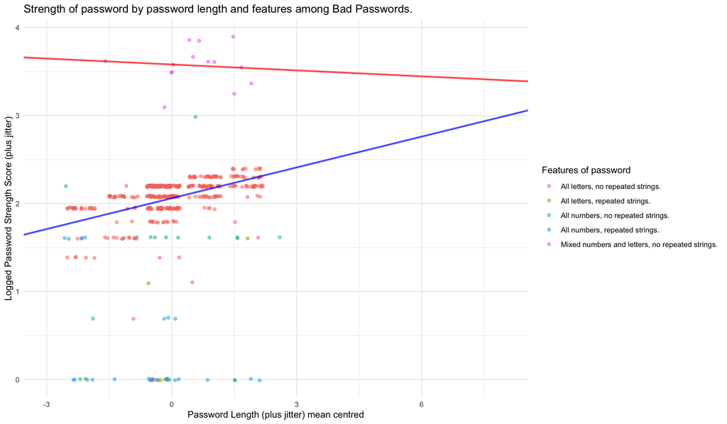

```r
## Plot model outputs for visualization
passwords_with_features %>% ggplot(
  aes(x = jitter(pw_len - mean(pw_len), 2),
      y = jitter(log(strength + 1), 2),
  col = pw_feat)) +
  geom_point(alpha = .5) +
  # regression line for numbers and letters together
  geom_abline(intercept = 3.58165, slope = -0.02250,
              alpha = .7,
              color = 'red',
              size = 1) +
  # regression line for all letters, no repeated strings
  geom_abline(intercept = 3.58165 + -1.52068,
              slope = -0.02250 + 0.13932,
              alpha = .7,
              color = 'blue',
              size = 1) +
  xlab("Password Length (plus jitter) mean centred") +
  ylab("Logged Password Strength Score (plus jitter)") +
  xlim(c(-3, 8)) +
  labs(col = "Features of password") +
  ggtitle("Strength of password by password length and features among Bad Passwords.") +
  theme_minimal()
```

From looking at these distributions and our fitted lines we may come to a few conclusions:

- “Stronger passwords have a mixture of letters and numbers, but the length is not a feature that makes these type of passwords stronger. It may even impede their strength.”
- “Letter-only passwords become stronger when they’re longer, when more characters are used.”

> The results we got support what this XKCD comic has to say about the number theory behind password strength. Really good data security advice!

[figure not shown]

**References :**

[Tidy Tuesday, ep. 14](https://www.tidytuesday.com/14)

[Calum Webb](https://www.calumwebb.uk/posts/tt-20200114-passwords/)

[XKCD](https://xkcd.com/936/)